# CA Contributions Analysis

#### by Arati Vaze

I chose the dataset “Financial Contributions to Presidential Campaigns by State” for my Exploratory Data Analysis Project. There, I chose year 2016 and California State.

# Univariate Plots Section

Structure of the dataset :

```
## 'data.frame':    1304346 obs. of  21 variables:
##  $ cmte_id          : Factor w/ 25 levels "C00458844","C00500587",..: 6 6 6 15 7 15 7 7 7 6 ...
##  $ cand_id          : Factor w/ 25 levels "P00003392","P20002671",..: 1 1 1 23 12 23 12 12 12 1 ...
##  $ cand_nm          : Factor w/ 25 levels "Bush, Jeb","Carson, Benjamin S.",..: 4 4 4 23 20 23 20 20 20 4 ...
##  $ contbr_nm        : Factor w/ 231294 levels "'CALL, BARBARA",..: 7753 31629 70312 175051 117924 176417 119377 119377 119411 92354 ...
##  $ contbr_city      : Factor w/ 2534 levels "","-4086","#NAME?",..: 1136 324 729 1183 323 1913 1810 1810 2402 1094 ...
##  $ contbr_st        : Factor w/ 1 level "CA": 1 1 1 1 1 1 1 1 1 1 ...
##  $ contbr_zip       : Factor w/ 143656 levels "","00000","000090272",..: 115155 71795 53864 126927 66455 139488 17327 17327 45924 58804 ...
##  $ contbr_employer  : Factor w/ 65600 levels "","''RETIRED''",..: 38794 38794 38794 27608 4491 27608 62116 62116 41406 38794 ...
##  $ contbr_occupation: Factor w/ 28622 levels "","''RETIRED''",..: 21476 21476 21476 12737 23942 12737 17980 17980 19679 21476 ...
##  $ contb_receipt_amt: num  50 200 5 48.3 40 ...
##  $ contb_receipt_dt : Factor w/ 732 levels "01-APR-15","01-APR-16",..: 596 446 27 486 85 564 108 132 85 446 ...
##  $ receipt_desc     : Factor w/ 74 levels "","* EARMARKED CONTRIBUTION: SEE BELOW REATTRIBUTION/REFUND PENDING",..: 1 1 1 1 1 1 1 1 1 1 ...
##  $ memo_cd          : Factor w/ 2 levels "","X": 2 2 2 2 1 2 1 1 1 2 ...
##  $ memo_text        : Factor w/ 428 levels "","$0.02 REFUNDED ON 10/21/2016",..: 126 126 126 1 90 1 90 90 90 126 ...
##  $ form_tp          : Factor w/ 3 levels "SA17A","SA18",..: 2 2 2 2 1 2 1 1 1 2 ...
##  $ file_num         : int  1091718 1091718 1091718 1146165 1077404 1146165 1077404 1077404 1077404 1091718 ...
##  $ tran_id          : Factor w/ 1300659 levels "A000771210424405B8CF",..: 466737 466019 463401 852428 1037145 890506 1038589 1040890 1036607 466057 ...
##  $ election_tp      : Factor w/ 5 levels "","G2016","O2016",..: 4 4 4 2 4 2 4 4 4 4 ...
##  $ party            : Factor w/ 5 levels "Democratic","Green",..: 1 1 1 5 1 5 1 1 1 1 ...
##  $ contb_year_month : chr  "16-04" "16-04" "16-04" "16-11" ...
##  $ contb_receipt_day: chr  "26" "20" "02" "21" ...
```

List of candidates in the dataset :

```
##  [1] "Bush, Jeb"                 "Carson, Benjamin S."
##  [3] "Christie, Christopher J."  "Clinton, Hillary Rodham"
##  [5] "Cruz, Rafael Edward 'Ted'" "Fiorina, Carly"
##  [7] "Gilmore, James S III"      "Graham, Lindsey O."
##  [9] "Huckabee, Mike"            "Jindal, Bobby"
## [11] "Johnson, Gary"             "Kasich, John R."
## [13] "Lessig, Lawrence"          "McMullin, Evan"
## [15] "O'Malley, Martin Joseph"   "Pataki, George E."
## [17] "Paul, Rand"                "Perry, James R. (Rick)"
## [19] "Rubio, Marco"              "Sanders, Bernard"
## [21] "Santorum, Richard J."      "Stein, Jill"
## [23] "Trump, Donald J."          "Walker, Scott"
## [25] "Webb, James Henry Jr."
```

Plot showing a count on each candidate in the data :

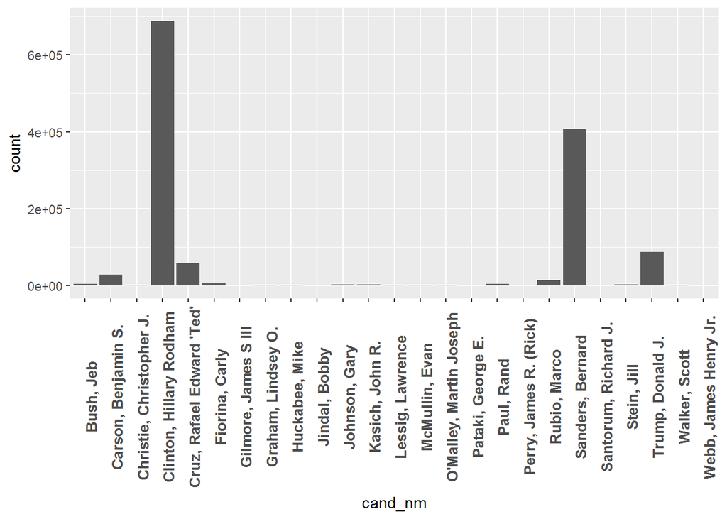

Political parties with their count in the dataset :

```
##  Democratic       Green Independent Libertarian  Republican
##     1096563        2842         306        1758      202877
```

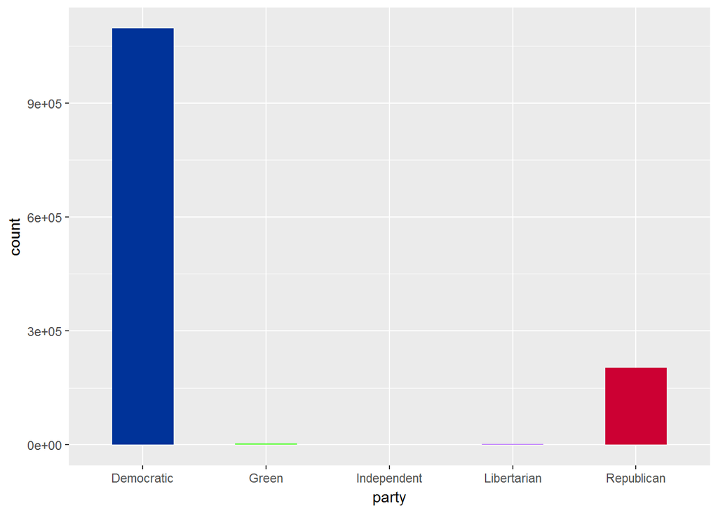

A look at the contribution amounts in dollars :

```
##     Min.  1st Qu.   Median     Mean  3rd Qu.     Max.
## -10500.0     15.0     27.0    116.2     88.0  10800.0
```

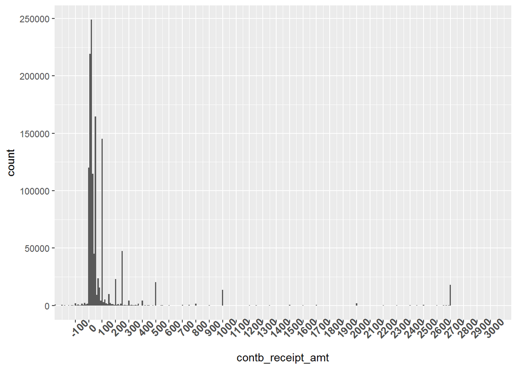

A closer look at the amounts most contributed :

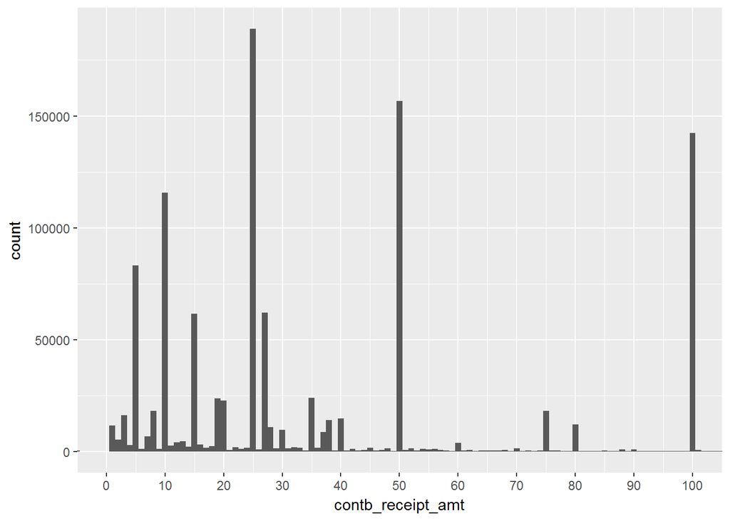

This plot shows that there are spikes at dollars 25,50,100,10,5,15,27. People tend to contribute in such round numbers, though 27 is a surprise. I also see an interesting spike at 2700. There are 53 entries in the dataset with contribution 0.

These are the top 20 contributors whose names appear most in the dataset :

```
##
##         PETIT, MICHAEL       MITCHELL, MARCIA          SMITH, CHERYL
##                    473                    409                    375
##        SAMATUA, DENISE          CARROLL, TERI          ADAM, MONIQUE
##                    373                    352                    321
##     MONTANELLI, TERESA         WHITE, DEBORAH         REYNOLDS, MARK
##                    317                    287                    282
##         MEISTER, JACOB          WEIL, MONIQUE           NGUYEN, DANH
##                    279                    257                    251
##        PENDERGAST, JAN        RAFAEL, EMERITA       MCLENNAN, MARLYN
##                    245                    242                    240
##     AUSLENDER, LEONARD PALMER, RICHARD A. MR.  KRISTENSEN, KATHERINE
##                    239                    235                    230
##     CHIORINO, JONATHAN            SOLT, SUSAN
##                    226                    223
```

Top 20 cities appearing the most in the dataset :

```
##
##    LOS ANGELES  SAN FRANCISCO      SAN DIEGO        OAKLAND       SAN JOSE
##         102710          90937          46129          33235          30674
##     SACRAMENTO       BERKELEY     LONG BEACH   SANTA MONICA       PASADENA
##          23799          23150          15757          14495          12865
##      PALO ALTO  SANTA BARBARA     SANTA CRUZ     SANTA ROSA         FRESNO
##          12105          11999          11504          11314           8907
##         IRVINE   WALNUT CREEK WEST HOLLYWOOD   SHERMAN OAKS      SUNNYVALE
##           8496           8233           8121           7648           7349
```

```
##
##                                    N/A
##                                 185382
##                                RETIRED
##                                 121569
##                          SELF-EMPLOYED
##                                 120187
##                                   NONE
##                                  84297
##                           NOT EMPLOYED
##                                  50821
##                          SELF EMPLOYED
##                                  38881
##                                   SELF
##                                  36395
##                  INFORMATION REQUESTED
##                                  30412
##
##                                  10522
##                    STATE OF CALIFORNIA
##                                   5884
##                                 GOOGLE
##                                   5002
##                      KAISER PERMANENTE
##                                   4769
## INFORMATION REQUESTED PER BEST EFFORTS
##                                   4205
##                              HOMEMAKER
##                                   4160
##                    STANFORD UNIVERSITY
##                                   3864
##                                   UCLA
##                                   3320
##               UNIVERSITY OF CALIFORNIA
##                                   3150
##                             APPLE INC.
##                                   2646
##    LOS ANGELES UNIFIED SCHOOL DISTRICT
##                                   2222
##                     LOS ANGELES COUNTY
##                                   1605
##     UNIVERSITY OF CALIFORNIA, BERKELEY
##                                   1603
##                            WELLS FARGO
##                                   1490
##                                 KAISER
##                                   1472
##                                   AT&T
##                                   1452
##                                  LAUSD
##                                   1387
##                    CITY OF LOS ANGELES
##                                   1292
##                               FACEBOOK
##                                   1248
##                               UC DAVIS
##                                   1156
##                 SELF EMPLOYED-EMPLOYED
##                                   1155
##      UNIVERSITY OF SOUTHERN CALIFORNIA
##                                   1089
```

Top 20 occupations of the contributers :

```
##
##               RETIRED          NOT EMPLOYED              ATTORNEY
##                260546                115598                 36640
## INFORMATION REQUESTED               TEACHER              ENGINEER
##                 30948                 29104                 17749
##             HOMEMAKER             PHYSICIAN     SOFTWARE ENGINEER
##                 17268                 16111                 15156
##             PROFESSOR            CONSULTANT                WRITER
##                 14949                 13961                 12654
##                                     MANAGER                 SALES
##                 10548                 10421                 10287
##                LAWYER      REGISTERED NURSE                ARTIST
##                  8945                  7439                  7303
##                   CEO               STUDENT
##                  7174                  7097
```

This distribution across contribution receipt months in the dataset shows that the number of contributions have peaks, one in March 2016 and then another in October 2016, the first one before primary elections and second one before general elections :

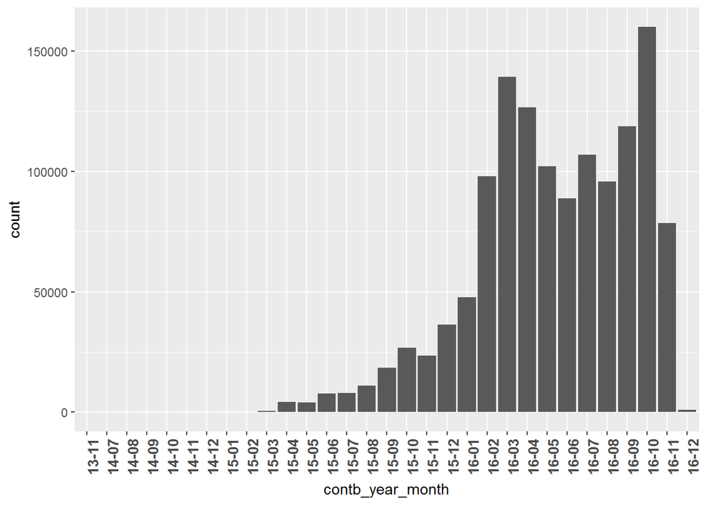

This distribution along days shows that contributions are more towards end of month with a peak on the 29 th :

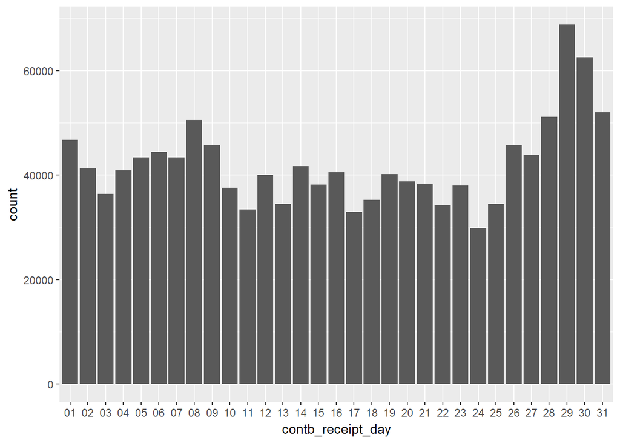

So I checked the top 20 dates when the contributions were highest :

```
##
## 29-FEB-16 31-MAR-16 31-MAY-16 31-OCT-16 06-NOV-16 01-NOV-16 04-NOV-16
##     11735     11506     10435     10220     10199     10082     10071
## 02-NOV-16 30-APR-16 26-SEP-16 07-NOV-16 03-NOV-16 29-OCT-16 08-JUN-16
##      9837      9479      9434      9431      9344      9078      8901
## 09-MAR-16 19-OCT-16 14-MAR-16 30-MAR-16 30-JUN-16 30-SEP-16
##      8887      8811      8559      8086      8018      8012
```

And it turns out that maximum number of contributions were received on the Leap Day - February 29, 2016.

Form Type indicates what schedule and line number the reporting committee reported a specific transaction :

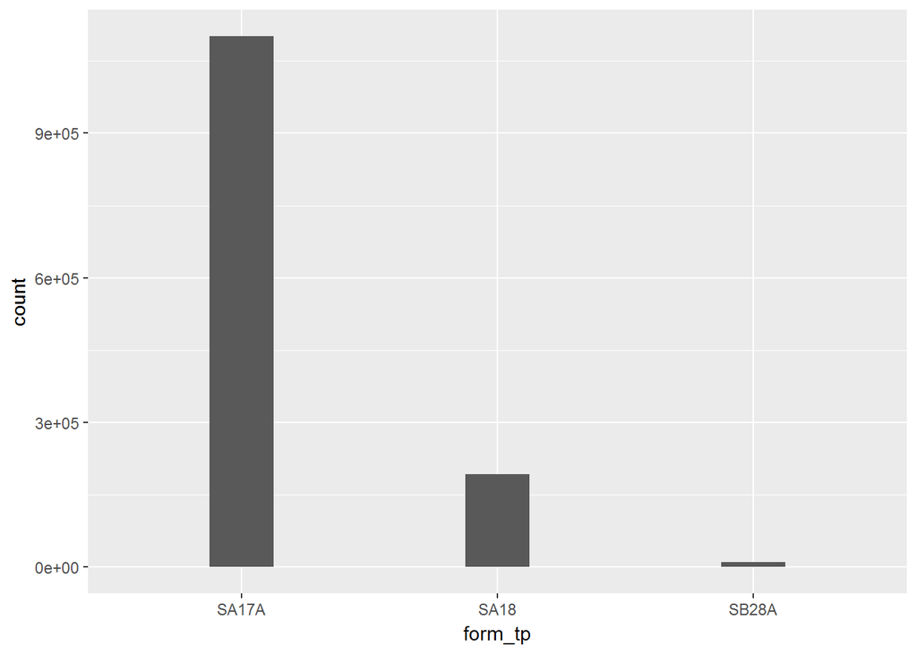

As can be seen from the plot and table below, highest number of contributions were towards the primary elections, followed by the general elections. P indicates Primary, G indicates General and O indicates Other:

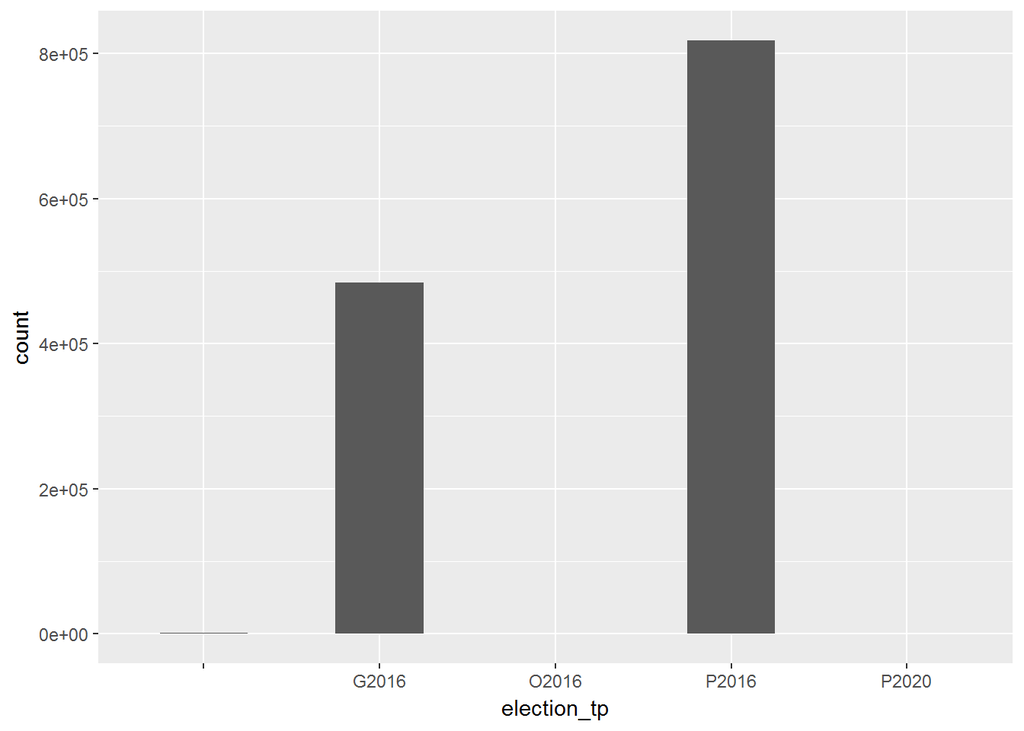

```
##
##         G2016  O2016  P2016  P2020
##   1695 483991    632 818021      7
```

# Univariate Analysis

### What is the structure of your dataset?

The dataset I chose for my analysis came as a text file, comma delimited, and with double-quotation marks as the text qualifier. I converted it to a dataframe with 18 variables and 1304346 observations. All except 2 variables are categorical.

The variables “cmte_id”, “cand_id”, “cand_nm” point to the 25 candidates who ran for the Presidential Elections in 2016. The “cmte_id” and “cand_id” are a 9-character alpha-numeric code assigned by the Federal Election Commission to the committee and candidate respectively.

The variables “contbr_nm”, “contbr_city”, “contbr_st”,“contbr_zip”, “contbr_employer”, “contbr_occupation” provide information about the contributors.

The variables “contb_receipt_amt”, “contb_receipt_dt”, “receipt_desc”, “memo_cd”, “memo_text”, “form_tp”, “file_num”, “tran_id”, “election_tp” provide information about the contributions.

### What is/are the main feature(s) of interest in your dataset?

The most significant information I found in the dataset was the contribution amount, and how it varies with the candidates.

### What other features in the dataset do you think will help support your investigation into your feature(s) of interest?

It was also interesting to find how the contribution amount varied with the contributor’s city, contribution date and election type. I also looked into all the other interactions between all the features of the dataset to find any surprises and interesting connections.

### Did you create any new variables from existing variables in the dataset?

I created a categorical variable “party”, based on the candidates. The dataset has 25 candidates from 5 political parties. It does not have data about some candidates like Constitution Party’s Darrell Castle, Party for Socialism and Liberation’s Gloria La Riva.

I created variables “contb_year_month” that extracts year-month, and “contb_receipt_day” that extracts day of the month, from the contribution dates.

I also created a variable “name” that merged the city name and the city state.

### Of the features you investigated, were there any unusual distributions? Did you perform any operations on the data to tidy, adjust, or change the form of the data? If so, why did you do this?

I saw that a few contributor names had white spaces on their left. Just to be cautious I trimmed the white spaces on both left and right sides of all contributor names.

The memo code “X” in the column “memo_cd” indicates that the reporting committee has provided additional text in the “memo_text”" column to describe a specific contribution. I checked to confirm and found that many more entries have provided additional text, even where there is no “X” as memo code. Also some entries that do have an “X”, do not have any text in the “memo_text” column. I did not change anything there.

I saw some unusual city names, some unusual zip codes.

I see that the dataset has 1304346 entries, so there should be that many unique transaction IDs, instead, there are 1300659. When I checked the entries that have common transaction IDs, I see that they are almost same except for any one of the columns that has some information entered differently.

# Bivariate Plots Section

A plot showing candidate names per party :

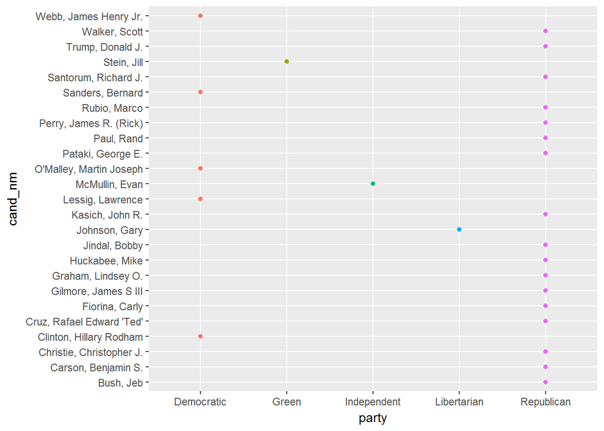

A plot showing distribution of candidates per election type :

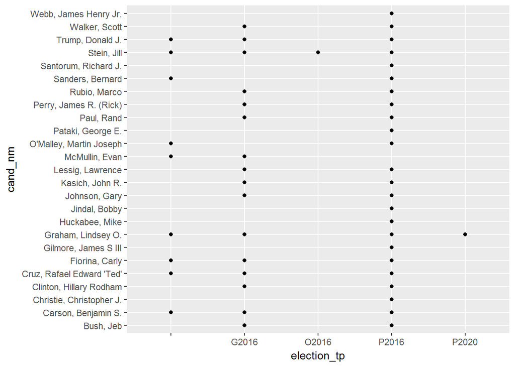

Interesting facts seen here are :

- All candidates except “McMullin, Evan” received contributions towards Primary 2016.
- Only “Graham, Lindsay O.” received contributions towards Primary 2020.
- Only “Stein, Jill” received contributions towards O2016, which is Other elections 2016.
- Few candidates received contributions with no election type indicated.
- Although only 5 of these candidates were on the ballot for General elections, 16 candidates received contributions towards it.

Distribution of contribution amount received per party :

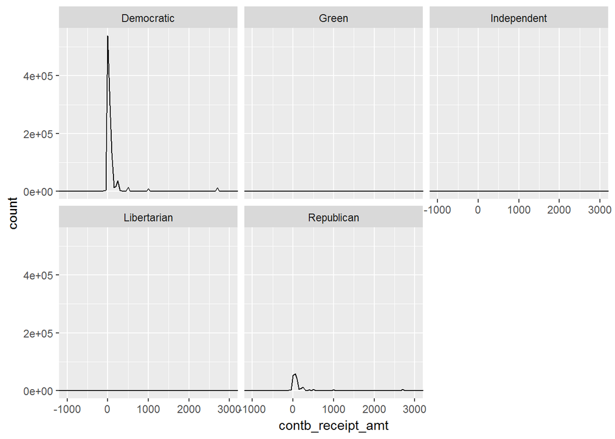

Instead of count, if I use density, which is proportion of count within the group, I can see the distribution as follows :

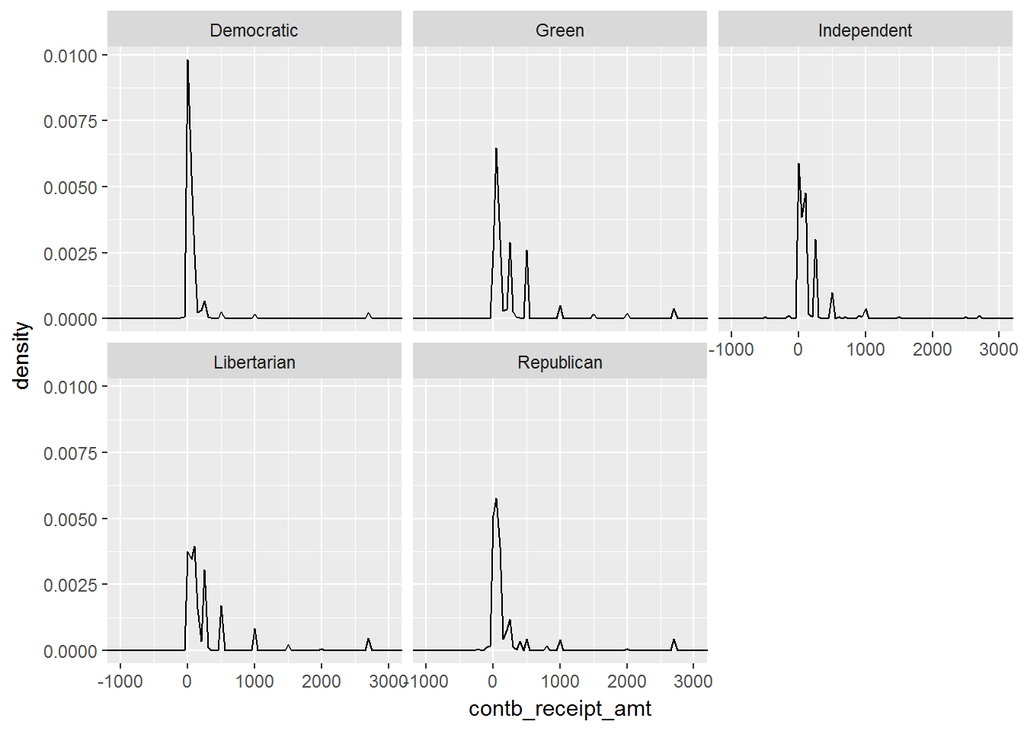

Summary of contribution amounts received per party :

```
## CA$party: Democratic
##     Min.  1st Qu.   Median     Mean  3rd Qu.     Max.
## -10500.0     15.0     27.0    103.8     65.0  10000.0
## --------------------------------------------------------
## CA$party: Green
##    Min. 1st Qu.  Median    Mean 3rd Qu.    Max.
##  -300.0    35.0   100.0   264.5   250.0  2700.0
## --------------------------------------------------------
## CA$party: Independent
##    Min. 1st Qu.  Median    Mean 3rd Qu.    Max.
##  -500.0    25.0   100.0   164.5   224.4  2700.0
## --------------------------------------------------------
## CA$party: Libertarian
##    Min. 1st Qu.  Median    Mean 3rd Qu.    Max.
##  -607.9    50.0   100.0   281.7   250.0  5000.0
## --------------------------------------------------------
## CA$party: Republican
##     Min.  1st Qu.   Median     Mean  3rd Qu.     Max.
## -10000.0     25.0     50.0    179.6    100.0  10800.0
```

Total contribution amounts received per party :

```
## CA$party: Democratic
## [1] 113866050
## --------------------------------------------------------
## CA$party: Green
## [1] 751784.6
## --------------------------------------------------------
## CA$party: Independent
## [1] 50335.5
## --------------------------------------------------------
## CA$party: Libertarian
## [1] 495230.6
## --------------------------------------------------------
## CA$party: Republican
## [1] 36440416
```

Total contribution amounts by top 20 cities :

```
## CA$contbr_city
##       LOS ANGELES     SAN FRANCISCO         SAN DIEGO         PALO ALTO
##          16220656          15376476           3849797           3261409
##           OAKLAND     BEVERLY HILLS          BERKELEY      SANTA MONICA
##           3150637           3125763           2863864           2854454
##          SAN JOSE        SACRAMENTO          PASADENA        MENLO PARK
##           2408418           2343078           1649200           1520624
## PACIFIC PALISADES     NEWPORT BEACH     SANTA BARBARA         LOS ALTOS
##           1490631           1484437           1480510           1321927
##        LONG BEACH            IRVINE      SHERMAN OAKS          ATHERTON
##           1184770           1172455           1091782           1086700
```

Total contribution amounts by top 20 contributors :

```
## CA$contbr_nm
##                 FLATLEY, JAY              MILLER, MICHAEL
##                     27000.00                     20717.77
##         BARTH, ANDREW F. MR.             BERGSTEIN, DAVID
##                     18900.00                     18900.00
## MATITYAHU, CHARLOTTE H. MRS.         NELSON, SUZANNE MRS.
##                     18900.00                     18900.00
##              NOTIS, MORDECAI                 PUZDER, ANDY
##                     18900.00                     18900.00
##            SALIMPOUR, PEJMAN              BANISTER, SCOTT
##                     18900.00                     18247.00
##             YOUNG, SAMUEL J.      GILBERT, LAMBERT O. MR.
##                     18100.00                     17423.00
##              HOROWITZ, DAVID                THOMAS, SUSAN
##                     17200.00                     16599.00
##               FARRELL, PETER     HARMON, MARTIN AARON MR.
##                     16200.00                     16200.00
##                SHAPIRO, JERI                   LEE, DAVID
##                     16200.00                     16051.00
##               MILLER, JOSEPH             MARTINEZ, MORIAH
##                     15732.00                     15400.00
```

Total contribution amounts by contributors with top 20 employers :

```
## CA$contbr_employer
##                          SELF-EMPLOYED
##                             20364850.0
##                                    N/A
##                             19001415.1
##                                RETIRED
##                             13405524.4
##                  INFORMATION REQUESTED
##                              5251780.2
##                           NOT EMPLOYED
##                              4005762.4
##                                   NONE
##                              3683813.6
##                          SELF EMPLOYED
##                              2999098.5
##                                   SELF
##                              2263521.3
##                              HOMEMAKER
##                              1787272.5
## INFORMATION REQUESTED PER BEST EFFORTS
##                              1459050.6
##                                 GOOGLE
##                              1167067.8
##                    STANFORD UNIVERSITY
##                               658966.8
##                             APPLE INC.
##                               551732.8
##                    STATE OF CALIFORNIA
##                               438433.9
##                      KAISER PERMANENTE
##                               391501.1
##               UNIVERSITY OF CALIFORNIA
##                               384224.0
##                               FACEBOOK
##                               382763.8
##                                   UCLA
##                               340153.7
##                         SALESFORCE.COM
##                               272739.0
##                CREATIVE ARTISTS AGENCY
##                               225410.1
```

Total contribution amounts by contributors with top 20 occupations :

```
## CA$contbr_occupation
##                                RETIRED
##                               25158880
##                               ATTORNEY
##                                8240915
##                           NOT EMPLOYED
##                                6484973
##                  INFORMATION REQUESTED
##                                5388307
##                              HOMEMAKER
##                                4800790
##                                    CEO
##                                3421376
##                              PHYSICIAN
##                                2644065
##                             CONSULTANT
##                                2503911
##                              PRESIDENT
##                                2354773
##                                 LAWYER
##                                2157174
##                               ENGINEER
##                                1987188
##                                 WRITER
##                                1745673
##                              PROFESSOR
##                                1720202
##                      SOFTWARE ENGINEER
##                                1681855
##                              EXECUTIVE
##                                1658648
##                                TEACHER
##                                1590401
##                                  OWNER
##                                1456789
##                               INVESTOR
##                                1412003
##                                MANAGER
##                                1347544
## INFORMATION REQUESTED PER BEST EFFORTS
##                                1315307
```

The top 20 frequent contributer employers and occupations appearing in the dataset are not necessarily the top 20 highest contributing, contributor employers and occupations.

Total contribution amounts on the top 20 dates :

```
## CA$contb_receipt_dt
## 30-SEP-16 30-JUN-15 26-SEP-16 30-SEP-15 29-JUL-16 27-SEP-16 02-NOV-16
## 1196693.6 1174152.9 1102602.8 1025069.2  993362.8  940391.8  904176.6
## 31-OCT-16 19-OCT-16 03-NOV-16 31-MAY-16 04-NOV-16 28-SEP-16 28-JUL-16
##  892538.0  881110.7  880960.5  855323.8  847978.4  838273.0  815098.4
## 29-SEP-16 31-AUG-16 29-FEB-16 01-NOV-16 18-OCT-16 31-DEC-15
##  804135.6  781171.5  778633.9  770799.4  727472.0  704451.7
```

So, although highest number of contributions were made on the Leap Day as mentioned earlier, the Day ranks 17th in terms of highest amount of contribution.

Contribution amounts histograms by party :

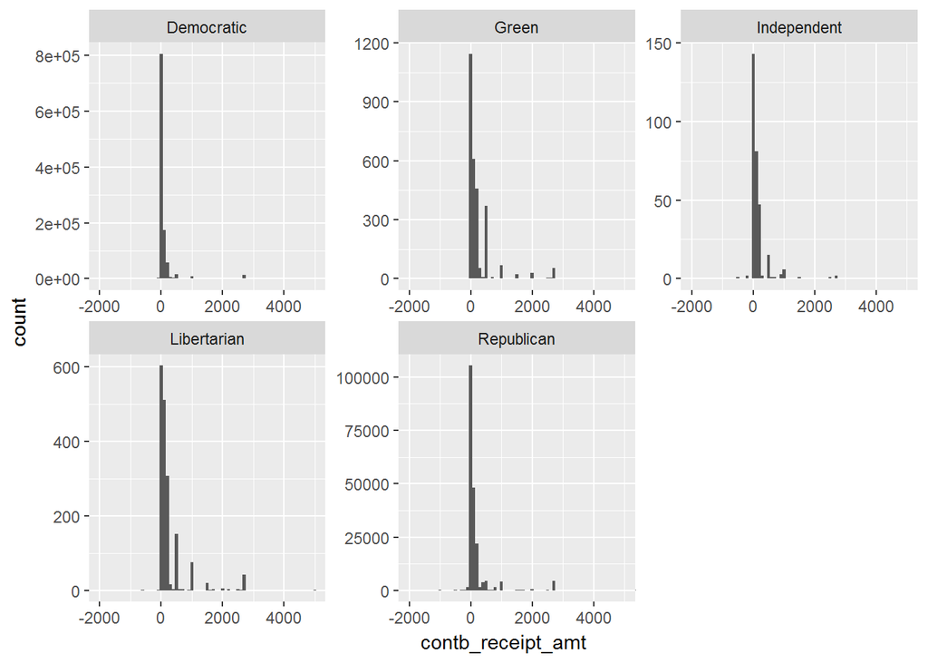

Total contribution amounts received per candidate :

```
## CA$cand_nm
##   Clinton, Hillary Rodham          Sanders, Bernard
##               93681170.76               19623832.71
##          Trump, Donald J. Cruz, Rafael Edward 'Ted'
##               14006381.29                5730682.27
##              Rubio, Marco                 Bush, Jeb
##                4838993.72                3300291.83
##       Carson, Benjamin S.           Kasich, John R.
##                2912555.00                1519569.54
##            Fiorina, Carly                Paul, Rand
##                1450689.42                 770938.29
##               Stein, Jill             Walker, Scott
##                 751784.61                 502201.90
##             Johnson, Gary  Christie, Christopher J.
##                 495230.56                 456066.00
##        Graham, Lindsey O.   O'Malley, Martin Joseph
##                 414495.00                 298334.26
##            Huckabee, Mike    Perry, James R. (Rick)
##                 230890.60                 208400.00
##          Lessig, Lawrence     Webb, James Henry Jr.
##                 186144.50                  76568.16
##            McMullin, Evan      Santorum, Richard J.
##                  50335.50                  36479.88
##         Pataki, George E.             Jindal, Bobby
##                  30450.00                  23231.26
##      Gilmore, James S III
##                   8100.00
```

The contribution mean and median for each political party, along with number of contributions for each party :

```
## # A tibble: 5 x 4
##         party contb_mean contb_median       n
##        <fctr>      <dbl>        <dbl>   <int>
## 1  Democratic   103.8390           27 1096563
## 2       Green   264.5266          100    2842
## 3 Independent   164.4951          100     306
## 4 Libertarian   281.7011          100    1758
## 5  Republican   179.6183           50  202877
```

This plot shows the mean contribution for each party and the size of each dot is proportional to the number of contributions for that party :

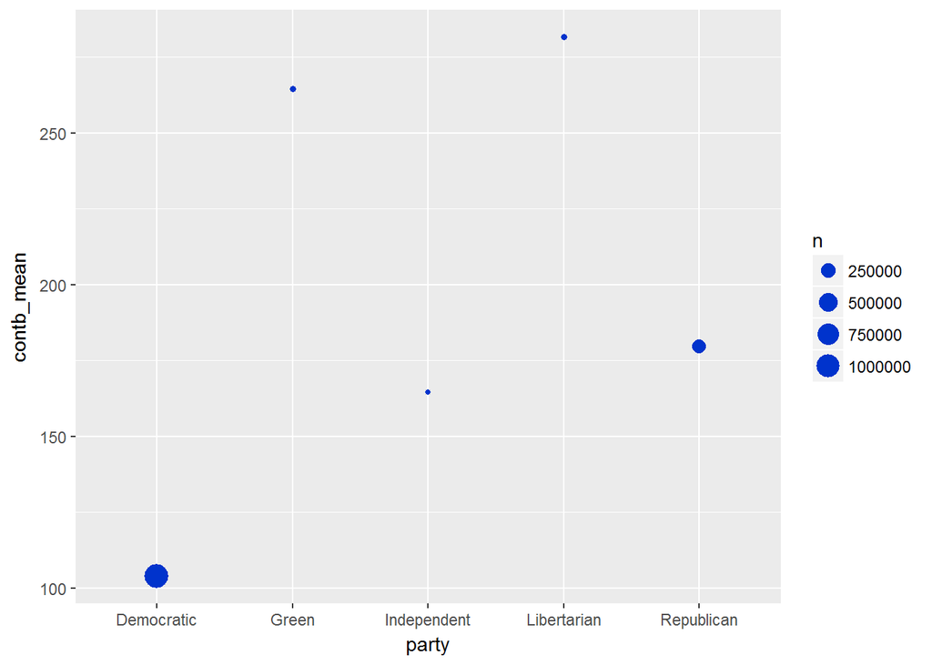

This plot shows the median contribution for each party and the size of each dot is proportional to the number of contributions for that party :

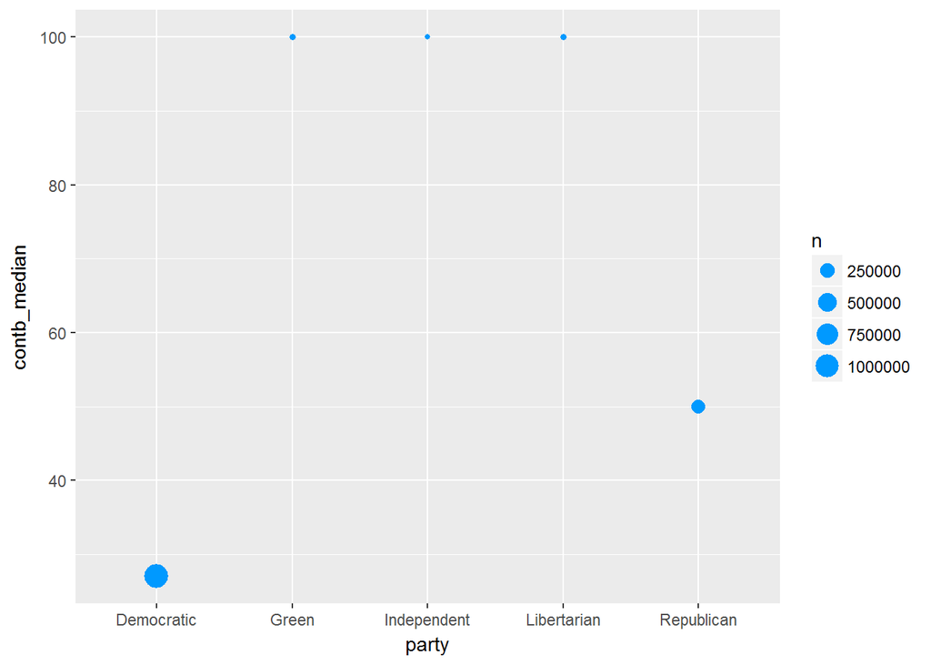

This plot shows the total amount of contribution received towards each type of election :

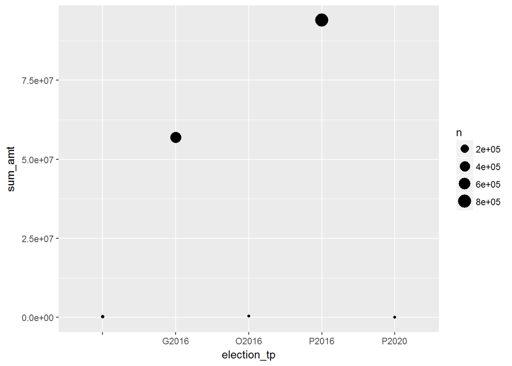

Earlier, in Univariate Plots we saw the number of contributions by year-month. Here I have added the feature “party” as color :

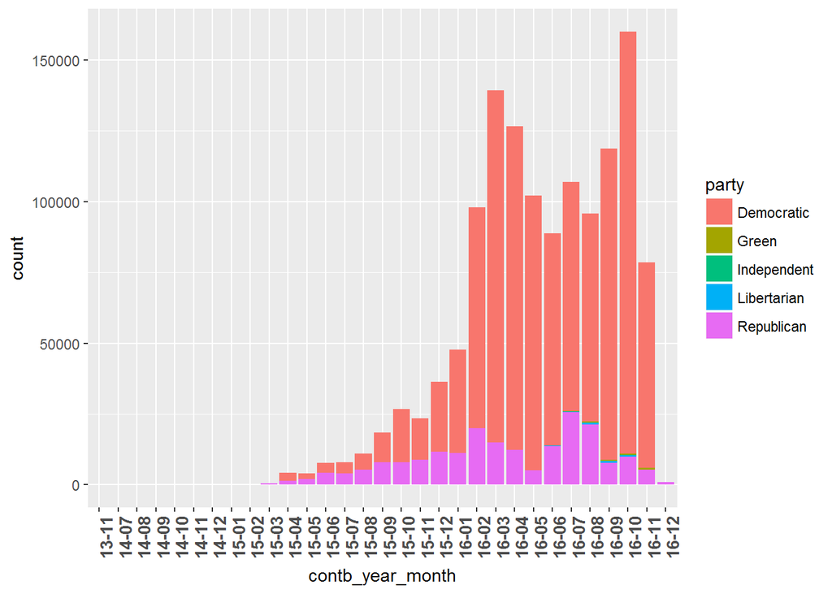

Top 50 highest contribution amounts received :

```
##  [1] 10800 10800 10800 10800 10800 10800 10800 10800 10800 10800 10800
## [12] 10800 10800 10800 10800 10800 10800 10800 10800 10800 10800 10800
## [23] 10800 10800 10800 10800 10800 10800 10800 10800 10800 10800 10800
## [34] 10000 10000 10000 10000 10000 10000 10000 10000 10000 10000 10000
## [45] 10000  8800  8800  8800  8800  8100
```

The above top 50 highest contribution amounts plotted against the respective candidates with the size of the dots indicating number of such contributions :

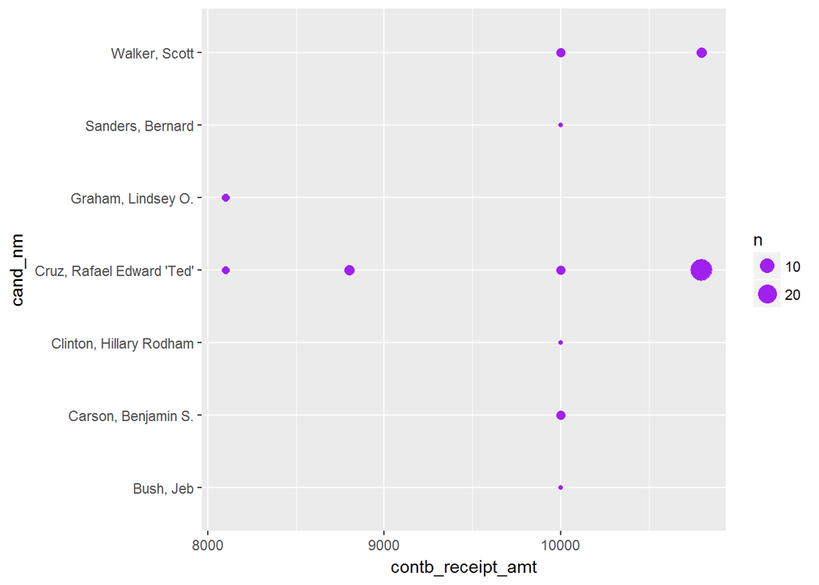

This plot shows that most of the top 50 highest contribution amounts in the dataset were received by “Ted Cruz”.

# Bivariate Analysis

### Talk about some of the relationships you observed in this part of the investigation. How did the feature(s) of interest vary with other features in the dataset?

It was very interesting to see the features in light of the other features.

In the Univariate section I had seen the general distribution of the contribution amounts in the dataset. In this Bivariate section I explored the contribution amounts with respect to cities, contributor occupations, their employers. I saw how the amount varies by dates, by election types. And of course it was interesting to see the amounts per party and also per candidate.

### Did you observe any interesting relationships between the other features (not the main feature(s) of interest)?

Not only the contribution amounts, I saw the candidates for different types of elections. I studied the relationships between contributor cities, contributor occupations and their employers. I saw the contributions for each candidate by dates.

### What was the strongest relationship you found?

I realized that when I explore the relationships between all the different features, it seems like there are innumerable angles of looking at the data. Each angle shows a new interesting fact about the data. For example, when I looked into the highest contribution amounts, I found out that most of those amounts were received by the Republican candidate Ted Cruz.

# Multivariate Plots Section

A matrix of total contribution amounts plotted per month, for all the candidates.

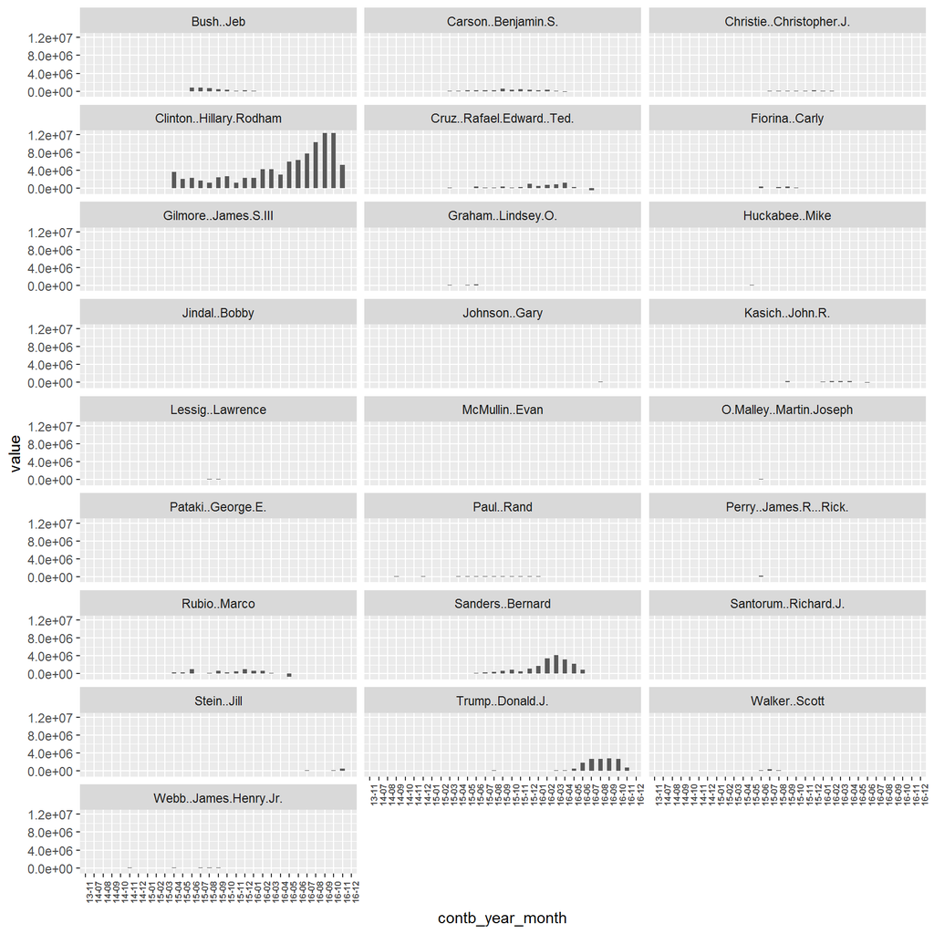

Plots of total contribution amounts plotted per month for the final five candidates on the ballot :

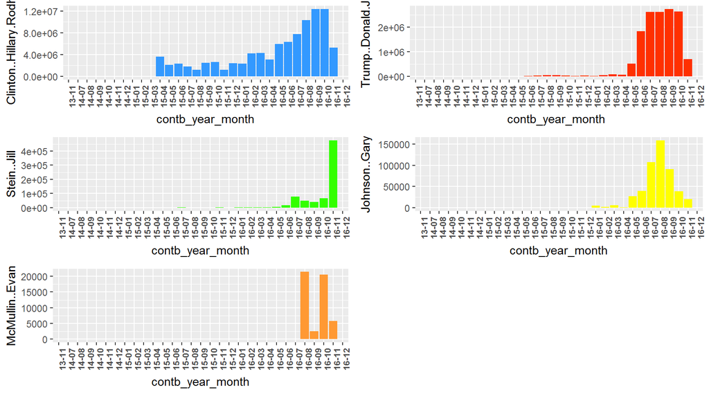

Correlation matrix of total contribution amounts per city for the candidates :

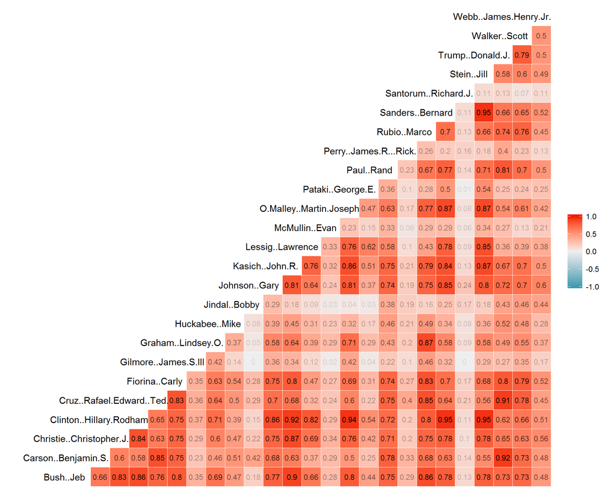

The pairs of candidates having a correlation coefficient close to 1 must be popular in common cities.

Plot of year-month against candidates plotting total contributions, with negative amounts indicating refunds, etc. :

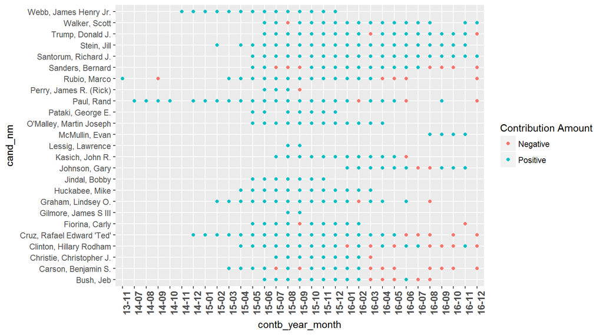

One can read from this plot, which month a candidate started campaign, and when ended.

This plot shows contribution amounts per month for each political party :

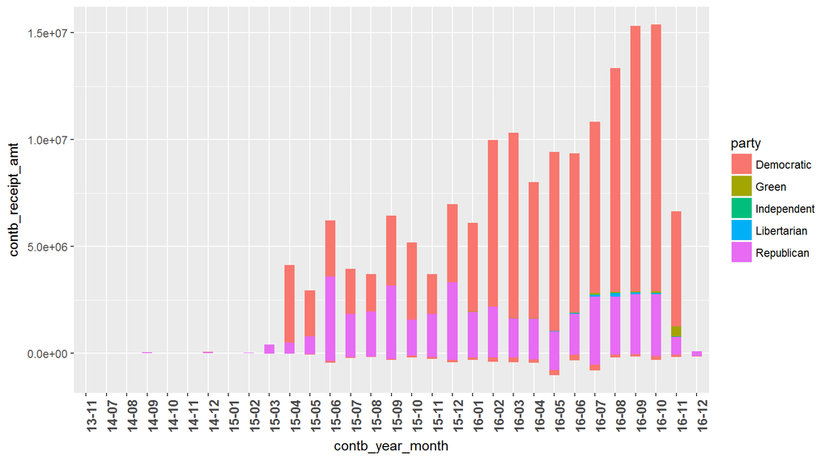

Scatterplot for samples :

There are 2534 cities in this dataset. By taking samples of all the cities in the dataset, we can look at various distributions :

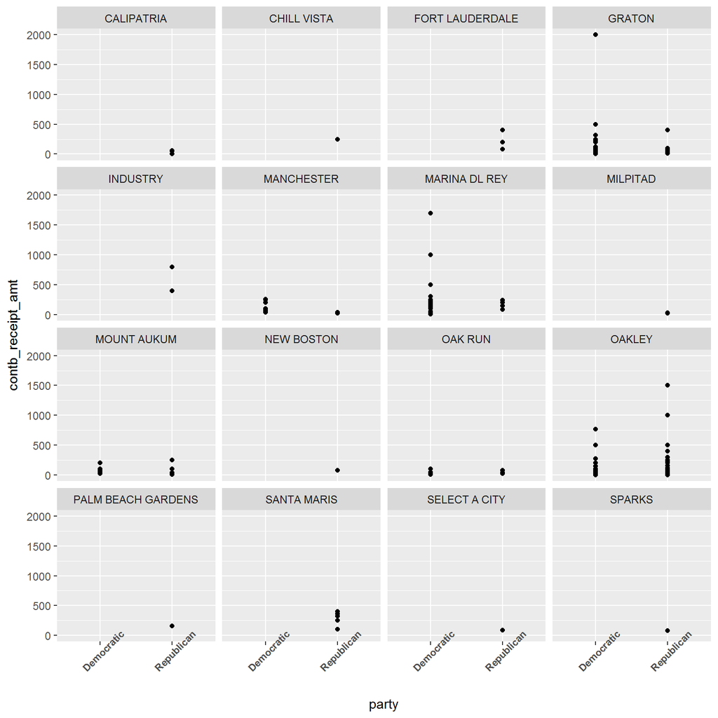

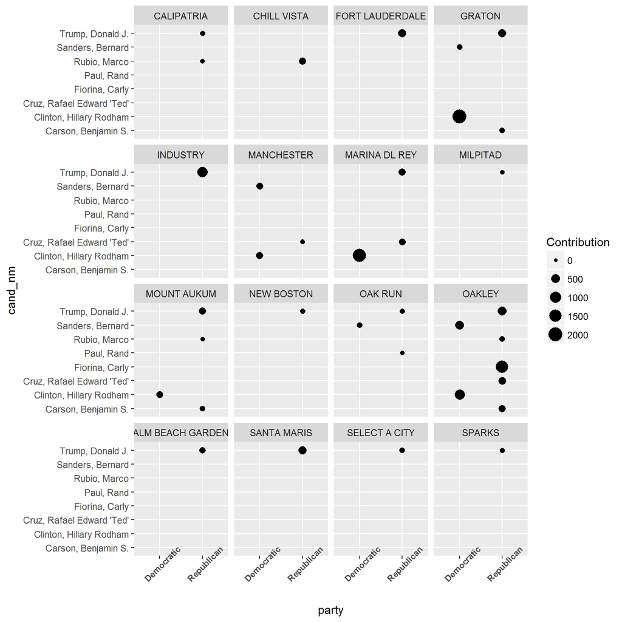

A HeatMap of year-months versus candidates showing distribution of contribution amounts with different colors and shades :

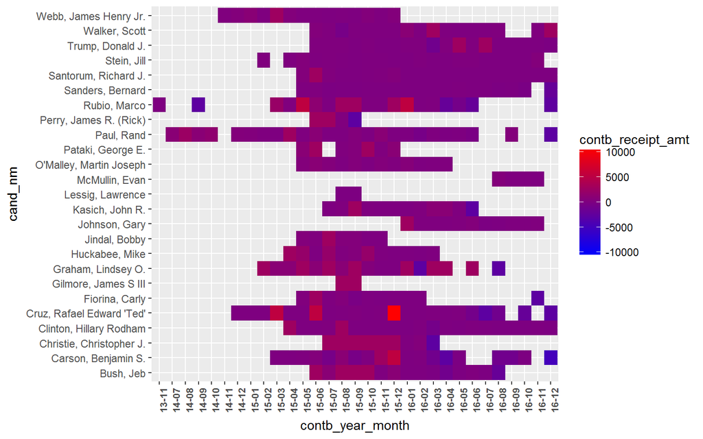

I have built a linear model for the contribution amount based on party and contribution receipt day from the data :

```
##
## Calls:
## m1: lm(formula = contb_receipt_amt ~ party, data = CA)
## m2: lm(formula = contb_receipt_amt ~ party + contb_receipt_day, data = CA)
##
## ===========================================================================
##                                          m1                   m2
## ---------------------------------------------------------------------------
##   (Intercept)                             103.839***            92.486***
##                                            (0.379)              (1.844)
##   party: Green/Democratic                 160.688***           157.514***
##                                            (7.455)              (7.456)
##   party: Independent/Democratic            60.656**             61.033**
##                                           (22.692)             (22.681)
##   party: Libertarian/Democratic           177.862***           177.608***
##                                            (9.473)              (9.470)
##   party: Republican/Democratic             75.779***            76.147***
##                                            (0.959)              (0.964)
##   contb_receipt_day: 02/01                                       2.166
##                                                                 (2.680)
##   contb_receipt_day: 03/01                                      23.817***
##                                                                 (2.774)
##   contb_receipt_day: 04/01                                      17.721***
##                                                                 (2.687)
##   contb_receipt_day: 05/01                                      -4.826
##                                                                 (2.646)
##   contb_receipt_day: 06/01                                      -7.118**
##                                                                 (2.628)
##   contb_receipt_day: 07/01                                      -3.315
##                                                                 (2.646)
##   contb_receipt_day: 08/01                                      -4.162
##                                                                 (2.546)
##   contb_receipt_day: 09/01                                      -4.185
##                                                                 (2.609)
##   contb_receipt_day: 10/01                                      -1.070
##                                                                 (2.750)
##   contb_receipt_day: 11/01                                      14.606***
##                                                                 (2.844)
##   contb_receipt_day: 12/01                                      -1.420
##                                                                 (2.703)
```

[output cut: 35 more lines]

```
##                                                                 (2.427)
##   contb_receipt_day: 31/01                                       1.417
##                                                                 (2.529)
## ---------------------------------------------------------------------------
##   R-squared                                 0.005                0.006
##   adj. R-squared                            0.005                0.006
##   sigma                                   396.890              396.684
##   F                                      1737.672              245.366
##   p                                         0.000                0.000
##   Log-likelihood                     -9655546.813         -9654854.900
##   Deviance                       205462169578.220     205244303313.044
##   AIC                                19311105.626         19309781.800
##   BIC                                19311178.113         19310216.724
##   N                                   1304346              1304346
## ===========================================================================
```

Based on this model, estimated contribution amount for Green Party without considering the receipt day would be (103.84 + 160.69), and considering receipt day would be (92.49 + 157.51 + 2.17) for second day of a month. For Republican Party, the contribution amount without considering receipt day would be (103.84 + 75.78), and considering receipt day would be (92.49 + 76.15 - 1.07) for tenth day of a month. Low R-squared value of 0.006 indicates a bad correlation between the variables.

Next I have plotted those cities in my dataset that have population greater than about 40,000, on the map of California. I have colored the cities by the party that got the most number of contributions :

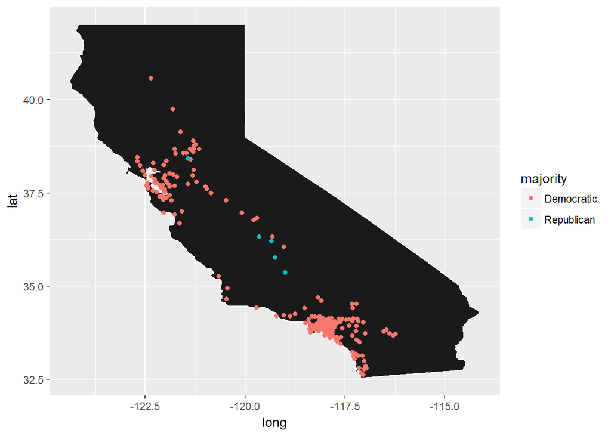

How many cities with population greater than about 40,000 , contributed most to each party ?

```
##
## Democratic Republican
##        198          5
```

So, out of the 203 cities with population greater than about 40,000 , 198 cities contributed mostly to the Democratic party and 5 cities contributed mostly to the Republican party. The other three parties received less number of contributions than these two.

This made me curious about all the cities in the dataset. How many cities contributed most to each party ?

```
##
##  Democratic       Green Independent Libertarian  Republican
##        1169          16           1          13        1335
```

Here we see an interesting fact. When we include the cities with population less than about 40,000 , we have more cities contributing most to the Republican party than the Democratic party. And some of the cities with less than 40,000 population gave most contributions to the other three parties too.

# Multivariate Analysis

### Talk about some of the relationships you observed in this part of the investigation. Were there features that strengthened each other in terms of looking at your feature(s) of interest?

It became more interesting when I started to look at 2 features in relation to a 3rd or even 4th feature.

For example by plotting the year-month versus the candidates, I could see when a particular candidate started and ended the campaign. But when I added a third feature, and colored the plot with total contribution amount per month, I could further see the negative amounts which meant that there were mostly refunds or transfers in those particular months.

Another example would be the California Map I plotted. For this I borrowed data about the longitudes, latitudes of the cities and the state. Then I plotted the selected highly populated cities and colored them according to the party that received highest number of contributions from that city.

When I plotted scatterplots for sample cities, I plotted the party versus candidates for each city, and plotted the points by size of the fourth feature, contribution amount.

### Were there any interesting or surprising interactions between features?

I was surprised to see that highly populated cities contributed highest to mainly the Democratic party and somewhat to the Republican party, whereas, less populated cities contributed highest to mainly the Republican party, next to Democratic party and also somewhat to the other 3 parties.

### OPTIONAL: Did you create any models with your dataset? Discuss the strengths and limitations of your model.

I built a linear model for the contribution amount based on party and contribution receipt day from the data. It is a huge data with mostly categorical variables with lots of levels. Hence I could not add any more variables. I believe the model can become a little stronger if I can add contribution city. I might also try borrowing county data and managing the large number of cities by gathering them into counties. My model was not a strong model looking at the low R-squared value of 0.006.

# Final Plots and Summary

### Plot One

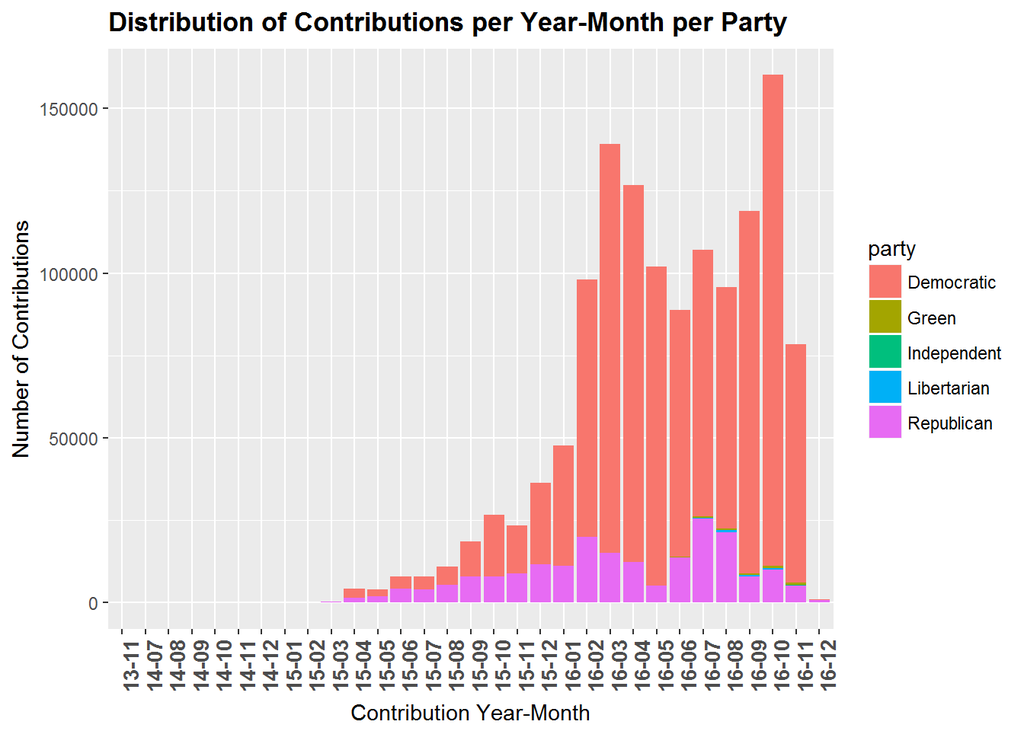

### Plot Two

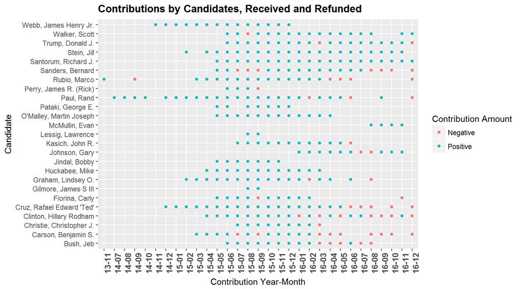

### Description Two

I find this plot very meaningful. First of all, it shows the length of each candidate’s campaign. The dots show which month a candidate’s contribution campaign began and when it ended. Furthermore, the color of the dots shows whether the contributions for a month were effectively received, seen as positive dots, or refunded, seen as negative dots.

For example, Bernie Sanders started his contribution campaign in May 2015 and ended in December 2016. During this time his total contribution for August, September, October and December 2016 was zero or negative, which was after he endorsed Hillary Clinton in July. Although, I wonder why he had zero or negative contributions in July, August and September 2015.

As a different example, Richard Santorum started his contribution campaign in May 2015 and ended in December 2016. His total contributions for all these months is positive. I wonder why he received contributions even after he ended his Presidential campaign in February 2016.

The plot points towards further analysis.

### Plot Three

[figure not shown]

### Description Three

I was able to get the Latitudes and Longitudes of cities with population greater than about 40,000 from the package “maps”. I combined that information with my dataset and was able to plot those cities on the map of California.

For each city I got a count on each political party. For each city I found the party that received highest number of contributions. I colored the cities on the map based on the political party that received the highest number of contributions from that city. I plotted the highly populated 203 cities, out of which 198 contributed **mostly** to the Democratic Party and 5 to the Republican Party.

If I had plotted all of the 2534 cities from my dataset, the colors on the map would have looked different. 1335 cities contributed **mostly** to the Republican Party, 1169 to the Democratic Party, 16 to the Green Party, 13 to the Libertarian Party and 1 to the Independent Party.

# Reflection

Working on this dataset was a delight.

The 2016 Presidential elections were fairly recent. Getting to know the campaign finances in depth was very insightful.

When I started, I had a rough idea of what I was going to analyze. As I explored, I began to see the power of Exploratory Data Analysis. I learned about the possibilities of looking at the data from different angles.

I had starting trouble because my csv file would not convert to dataframe as I would like it to. Eventually I figured out the right way.

Many times it so happened that I would want to plot certain features, but realized that the plots turned out to be too cluttered. Then I had to find a way out, sometimes by taking samples, sometimes by clustering the data. Even then, the patterns I could see in the plots encouraged me to look for more.

Some times it seemed easy to jump to conclusions, but I recognised the flaw in doing so. Deducing from plots is very powerful only if it is done right. Otherwise it can simply give wrong results.

I would suggest that the dataset should add the contributor’s gender and age. That information would help in making the linear model better.

This dataset is useful in getting an insight for future election campaigns. Without looking at the individual candidates, the contributions received by each party from the beginning of the campaign period shows the inclination of different cities. Of course, the individual candidates come next and are as important. The dataset shows the inclination of people from various occupations. It also shows the timeline of contributions which can be helpful.